# Data Science Capstone: Milestone Report

R. Holley

9/02/2020

## Introduction

This report records the progress made for Johns Hopkins University/Coursera’s Data Science capstone project. The project goal is to create a mobile app (hosted on a web page) that, given a string of words, will predict the next word. This app cannot be too intensive, as it must be able to run on a web page or mobile device. Yet it cannot be so innacurate as to be useless - balancing accuracy and speed is the crux of this project. The processing and analysis mentioned in this report utilizes the following R packages: *tm*, *quanteda*, *parallel*, *doParallel*, *dplyr*, *ngram*.

## The Data

The datasets available to build a text-prediction model were provided by SwiftKey, the text-predictive keyboard available for iOS and Android devices. There are 3 large datasets in English: news articles, blog posts, and Twitter tweets. In language processing lingo, a group of documents for analysis is called a *corpus*; it is also the name of a specific data type for R text-mining packages. In this project, each file - news, blogs, or tweets - forms a corpus. Exploratory analysis and code-testing were predominately focused on the news dataset, but the referenced code can work with any of the three corpii. Following is a basic summary - word counts and lines counts - for each file, with no kind of pre-processing.

```r
con1 <- file("./final/en_US/en_US.news.txt")
con2 <- file("./final/en_US/en_US.blogs.txt")
con3 <- file("./final/en_US/en_US.twitter.txt")

print(paste("News Lines:",length(readLines(con1, skipNul = TRUE))))
print(paste("News Word Count:", wordcount(readLines(con1, skipNul = TRUE))))

print(paste("Blogs Lines:",length(readLines(con2, skipNul = TRUE))))
print(paste("Blogs Word Count:", wordcount(readLines(con2, skipNul = TRUE))))

print(paste("Tweets Lines:",length(readLines(con3, skipNul = TRUE))))
print(paste("Tweets Word Count:", wordcount(readLines(con3, skipNul = TRUE))))

close(con1, con2, con3)
```

```
## [1] "News Lines: 1010242"
## [1] "News Word Count: 34372530"
## [1] "Blogs Lines: 899288"
## [1] "Blogs Word Count: 37334131"
## [1] "Tweets Lines: 2360148"
## [1] "Tweets Word Count: 30373583"
```

Each dataset is massive, so loading and organizing the files is the first challenge. I used `readLines()` and `corpus` to create corpus data. All following cleaning and analyzing takes advantage of parallel processing and functions such as `parLapply()` to drastically cut down on runtime.

### Cleaning and Organizing

The news articles seem to be scraped from web pages, and often include phone numbers or emails in site footers. These are examples of a few things for which I wrote a function (`myFilter`) to clean up. The entire code for this filter is available on my github page [(repository DSCapstone/myFilter.R) located here](https://github.com/MementoMakoMori/DSCapstone/blob/master/myFilter.R). Running `myFilter(corpus)` accomplishes the following:

- Removes non-ASCII characters with `inconv()` function
- Removes urls, email addresses, and numbers with `gsub()` function
- Converts contractions into two separate words with `gsub()` function
- Splits the corpus into five sections for parallel processing
- Restructures the corpus chunks from news article entries to sentence entries with `corpus_reshape()` function and parallel processing
- Returns a list of the five corpus chunks for further processing

This is a good starting point for the word-order analysis.

## Exploratory Analysis

The quanteda function `textstat_collocations()` identifies multi-word expressions (in this case, pairs) and scores them accordingly. Collocation is similar to n-grams; I chose the collocation function specifically because of the simplicity of the output. I chose the numeric ‘*count*’ variable for an easy-to-compare measurement of n-gram (word pair) frequency. The output of the collocation function on each corpus, with the *count* variable added when appropriate and the results cleaned of extraneous information, is two columns: the first variable is the two-word phrase, the second variable is the number of times it appears. Below are the first few lines of this datatable.

| collocation | count |
| --- | --- |
| it is | 34025 |
| more than | 12445 |
| in the | 78667 |
| of the | 84790 |
| will be | 10536 |
| if you | 9986 |

For an example usecase of the collocation data, I will search for the word ‘rather’ and chart the most likely following words.

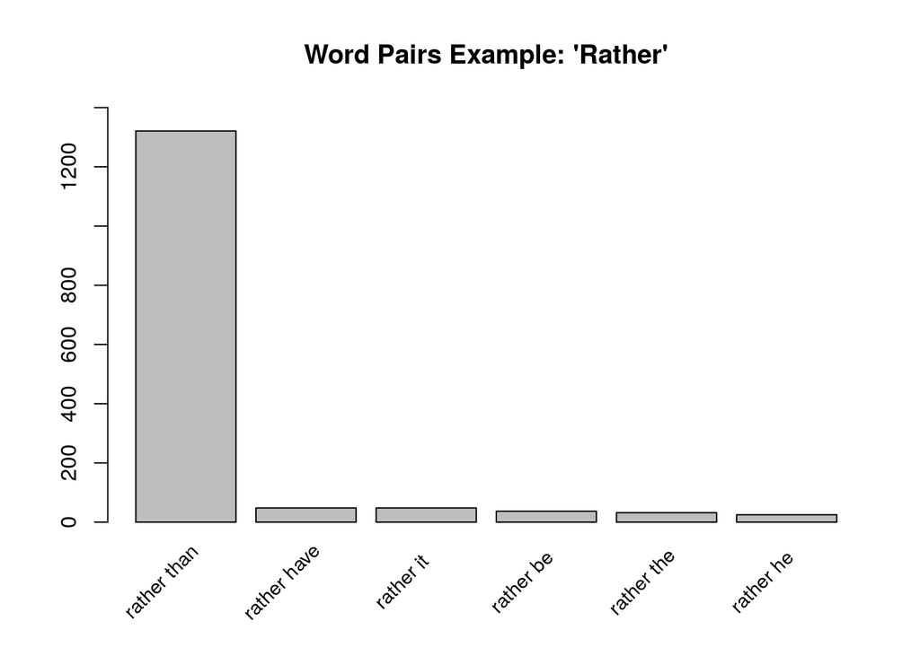

```r
matches <- combs[which(grepl("rather ", combs$collocation, ignore.case=TRUE))]
matches <- arrange(matches, desc(count))

x <- barplot(height=head(matches$count), ylim=c(0,1400), main="Word Pairs Example: 'Rather'")
labs <- paste(head(matches$collocation))
text(cex=0.9, x=x-.25, y=-200, labs, xpd=TRUE, srt=45)
```

‘Rather than’ is clearly the most likely combination, so the algorithm in the final app should return ‘than’ to the user.

## Plans for the App

The collocation data could be the backbone of prediction app that uses regular expressions (REGEX) and simple search function. Consider that the user inputs a word *string*; that word is the search term (using REGEX to specify the first word in a two-word pair). The regex function would produce all rows in which *string* appears as the first word. The app would in turn output to the user the second word in the row with the highest *count* variable. This type of design is user-oriented and makes sense from an outward perspective, but is it the most efficient? A dictionary-style Markov-chain may be faster for the end product, as the user-input *string* would point directly to one specific data line. However, the processing to create a Markov-chain dictionary may be beyond the capabilties of my computers The next two weeks of the project will be experimenting with and fine-tuning an algorithm to search through and organize the data, so I will experiment with both n-gram collocations and Markov chains.